# Plotting and Animation Intro

Joseph Abolt

April 13, 2019

## Load Libraries

```r
# install.packages('knitr', repos = c('http://rforge.net', 'http://cran.rstudio.org'), type = 'source')
# install.packages("ggplot2")
# install.packages("gganimate")
# install.packages("gifski")
# install.packages("png")
# install.packages("transformr")
library("knitr")
library("ggplot2")
library("gganimate")
library("gifski")
library("png")
library("transformr")
```

### GGPlot reference

https://ggplot2.tidyverse.org/reference/index.html

### GGAnimate reference

https://www.rdocumentation.org/packages/gganimate/versions/1.0.2 Possibly superior: https://gganimate.com/reference/index.html

## Core Concepts

- ggplot accepts all the inputs (each layer can override as necessary)
- inputs given as “aesthetics” via the function aes()
  - usually inherited; to override, set inherit.aes = F
- add prototypes to apply visualizations to the data
  - e.g., geom_point() creates scatterplots

## GGPlot Scatterplot

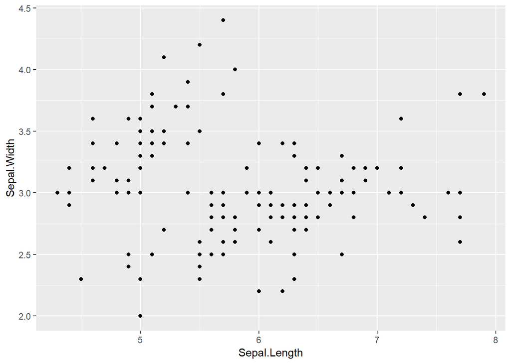

```r
irisData <- iris
ggplot(data = irisData, aes(x=Sepal.Length, y=Sepal.Width)) +
  geom_point()
```

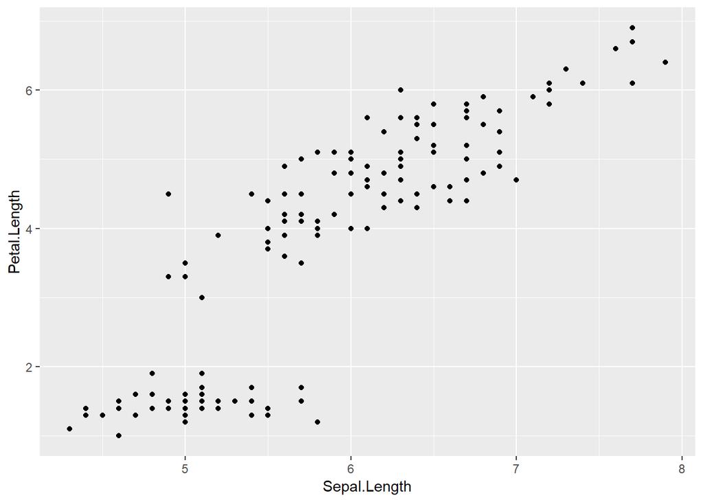

```r
ggplot(data = irisData, aes(x=Sepal.Length, y=Petal.Length)) +
  geom_point()
```

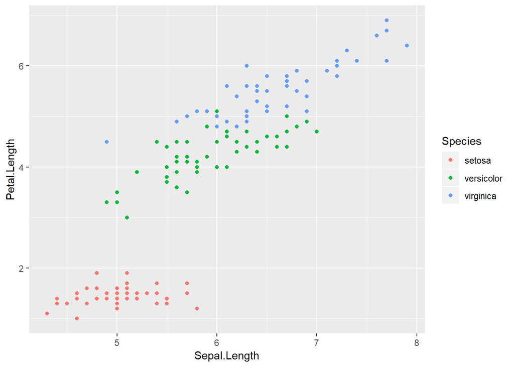

```r
# Add extra aesthetic to color points correctly - will only apply to the scatterplot
ggplot(data = irisData, aes(x=Sepal.Length, y=Petal.Length)) +
  geom_point(aes(colour = Species))
```

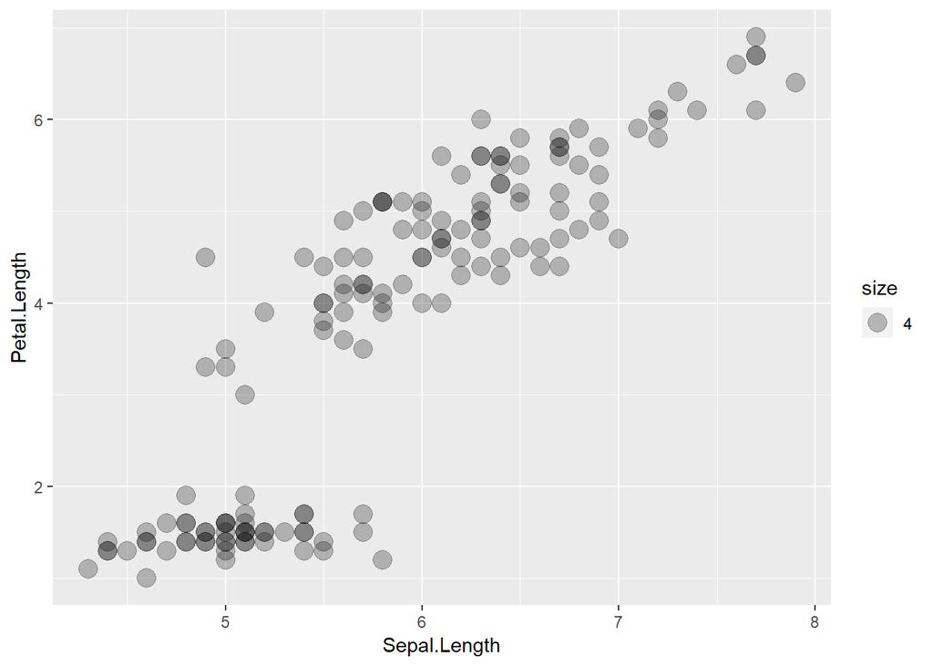

```r
# Display overlap by increasing size and decreasing alpha
# Note: alpha is not an aesthetic
ggplot(data = irisData, aes(x=Sepal.Length, y=Petal.Length)) +
  geom_point(aes(size = 4), alpha = 1 / 4)
```

## GGPlot Lines

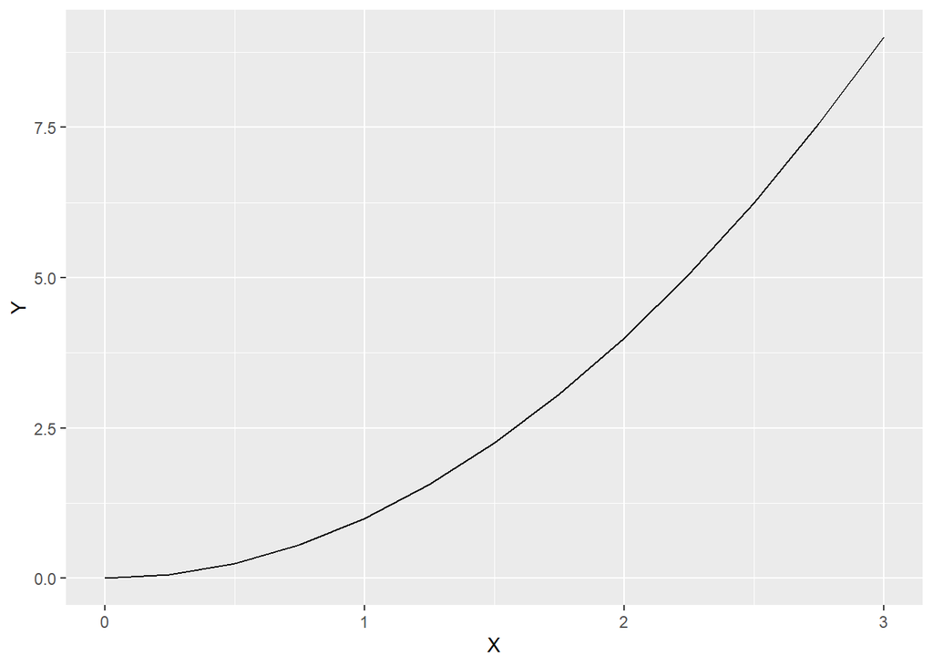

```r
# Construct data and randomize order
data <- data.frame(X = seq(0, 3, 0.25), Y = seq(0, 3, 0.25)^2)
data <- data[sample(nrow(data), nrow(data)),]

# geom_line() plots in ascending order along the x-axis
ggplot(data, aes(X, Y)) +
  geom_line()
```

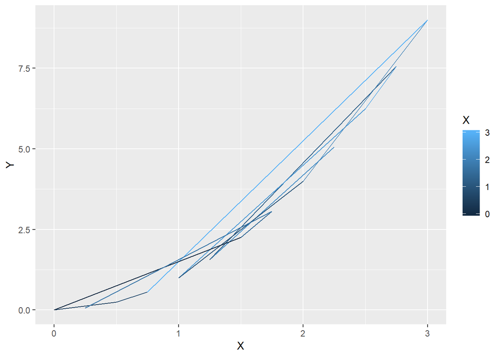

```r
# geom_path() uses the order of the data
# color can be used to distinguish earlier and later values
ggplot(data, aes(X, Y)) +
  geom_path(aes(colour = X))
```

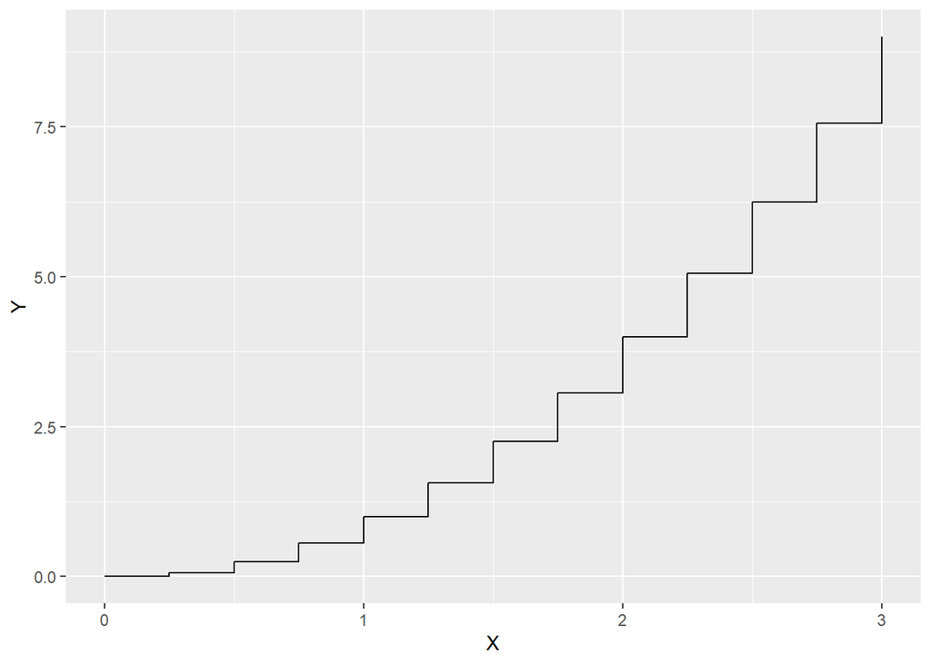

```r
# geom_step() can emphasize precisely when data changed
ggplot(data, aes(X, Y)) +
  geom_step()
```

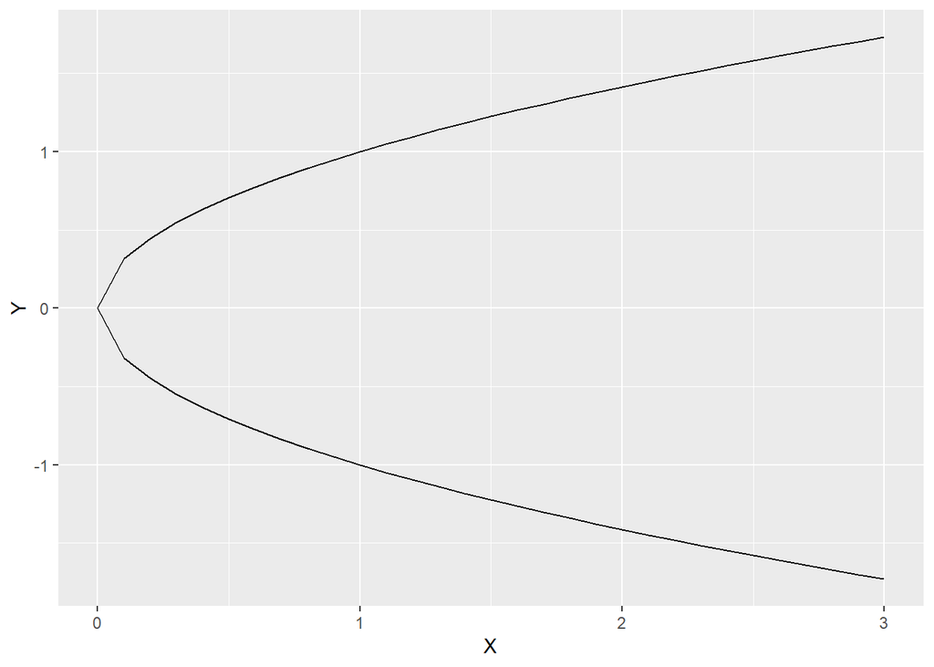

```r
# New data - square roots
sequence <- seq(0, 3, 0.1)
data <- data.frame(X = c(rev(sequence), sequence), Y = c(-1 * sqrt(rev(sequence)), sqrt(sequence)))

# Since geom_path() does not order the data, it can plot non-functions like sqrt
ggplot(data, aes(X, Y)) +
  geom_path()
```

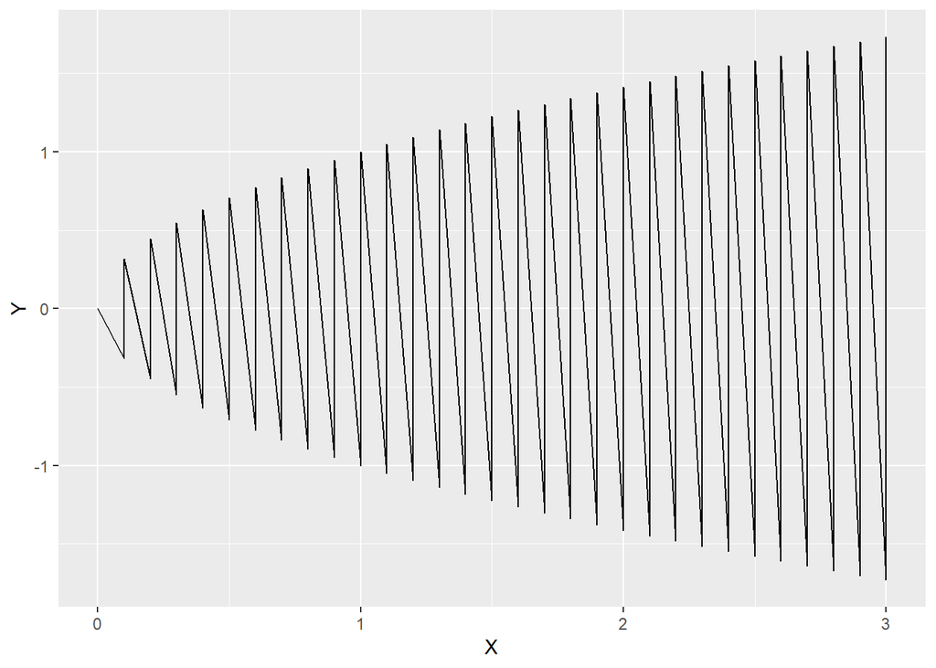

```r
# geom_line(), on the other hand, will be unhelpfully creative
ggplot(data, aes(X, Y)) +
  geom_line()
```

## GGPlot Countours

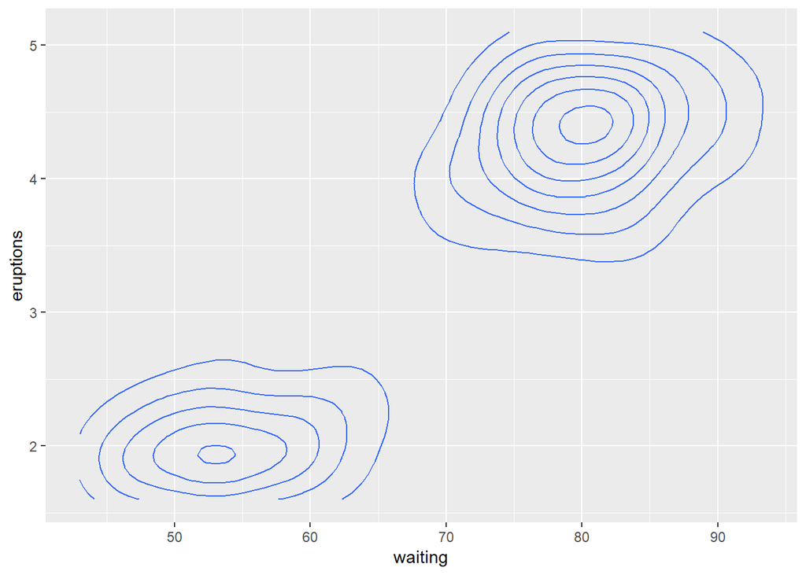

```r
ggplot(faithfuld, aes(waiting, eruptions, z = density)) +
  geom_contour()
```

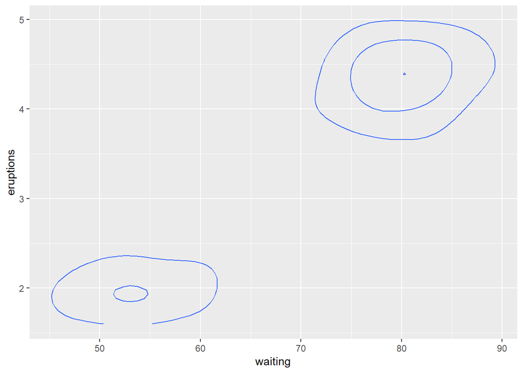

```r
# Control number of contours
ggplot(faithfuld, aes(waiting, eruptions, z = density)) +
  geom_contour(bins = 3)
```

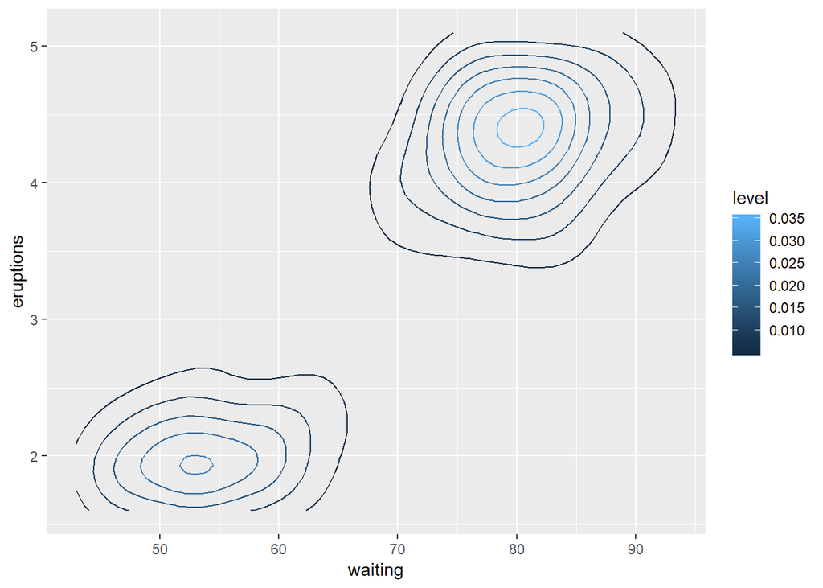

```r
# Fancy coloring 1
ggplot(faithfuld, aes(waiting, eruptions, z = density)) +
  geom_contour(aes(colour = stat(level)))
```

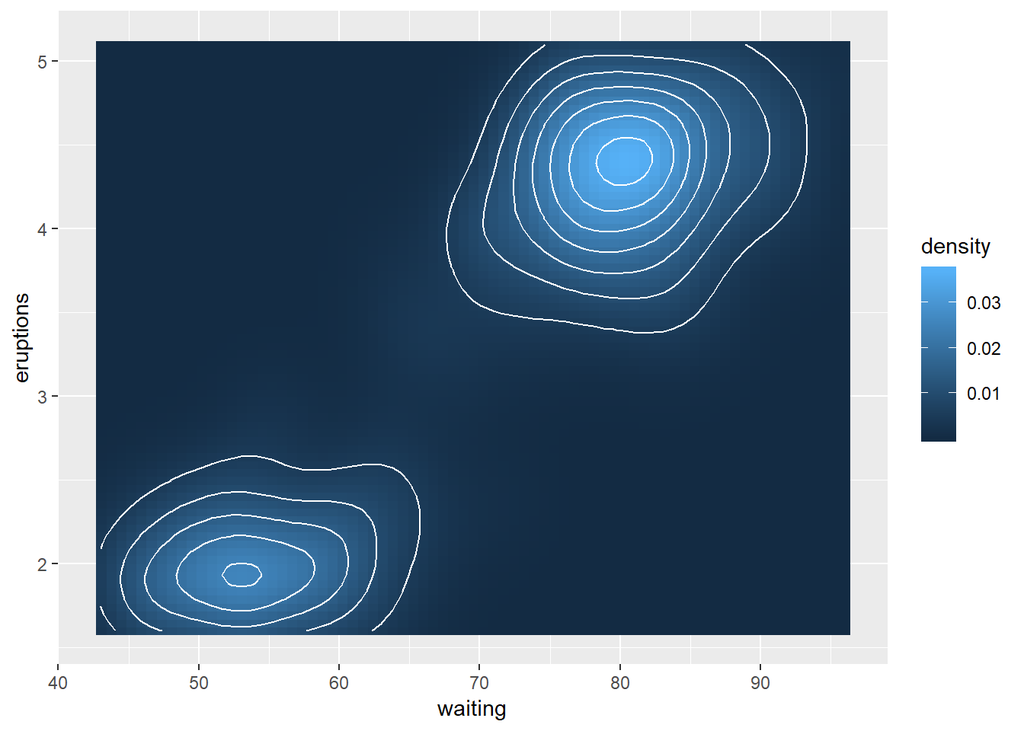

```r
# Fancy coloring 2
ggplot(faithfuld, aes(waiting, eruptions, z = density)) +
  geom_raster(aes(fill = density)) +
  geom_contour(colour = "white")
```

## The Group Aesthetic

- Single most confusing concept in ggplot
- Provide another variable used to group your data
- Simple once you have it, but can be difficult to wrangle

Examples will be shown below with GGAnimate. When only drawing one graph, it is almost always better to use color, shape (for points), linetype (for line graphs), or facets (a way to create multiple graphs side-by-side; check the documentation for this) instead. This is because group does not change the styling between groups - they will appear nigh-indistinguishable.

# GGAnimate

GGAnimate is a package that creates a large number of ggplot images and combines them into a gif. It is used almost identically to ggplot.

Unlike ggplot, gganimate is significantly less standardized in its parameters. Make sure you check the documentation to find the most appropriate tool.

### GGAnimate reference

https://www.rdocumentation.org/packages/gganimate/versions/1.0.2 Possibly superior: https://gganimate.com/reference/index.html

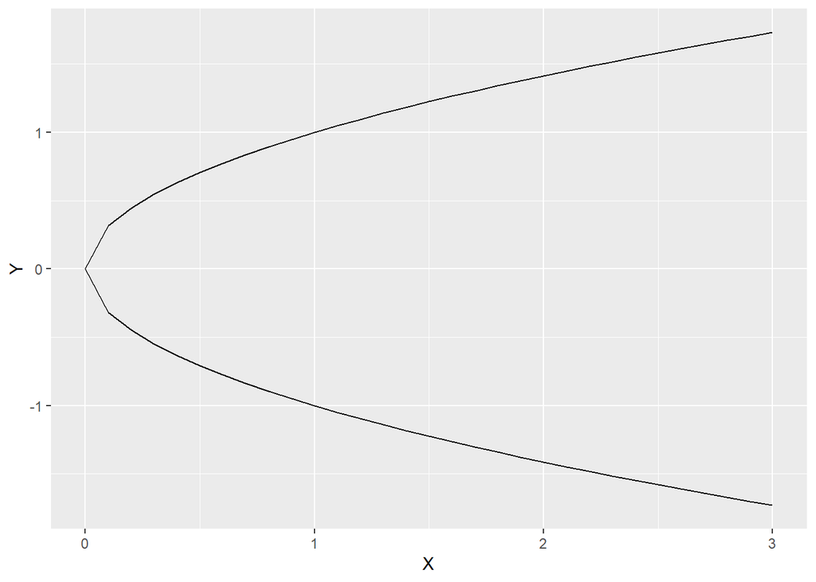

```r
# The square root function
sequence <- seq(0, 3, 0.1)
data <- data.frame(X = c(rev(sequence), sequence), Y = c(-1 * sqrt(rev(sequence)), sqrt(sequence)))

# An ordinary plot
ggplot(data, aes(X, Y)) +
  geom_path()
```

[figure not shown]

```r
# An animated plot
ggplot(data, aes(X, Y)) +
  geom_path() +
  transition_reveal(X)
```

```r
# Note: when knitting, only one animation per chunk
```

[figure not shown]

```r
# Adding different transitions and changing their parameters changes how the function is animated

# transition_reveal() takes a single paramter determining which values are being revealed
# The above was left to right; this will be bottom to top
ggplot(data, aes(X, Y)) +
  geom_path() +
  transition_reveal(Y)
```

## Temperature by Month

An example by Thomas Lin Penderson Source: https://github.com/thomasp85/gganimate/wiki/Temperature-time-series Comments added by myself

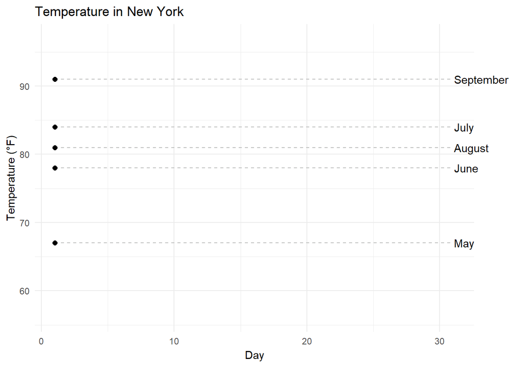

```r
airq <- airquality
airq$Month <- format(ISOdate(2004,1:12,1),"%B")[airq$Month]

ggplot(airq, aes(Day, Temp, group = Month)) +
  geom_line() + # Draw the line of temperature over time
  geom_segment(aes(xend = 31, yend = Temp), linetype = 2, colour = 'grey') + # Connect line to month label at right
  geom_point(size = 2) + # Draw point at end of line
  geom_text(aes(x = 31.1, label = Month), hjust = 0) + # Moving month label at right
  transition_reveal(Day) + # Create the animation, day-by-day
  coord_cartesian(clip = 'off') + # Not sure - styling of some sort
  labs(title = 'Temperature in New York', y = 'Temperature (°F)') + # Add labels
  theme_minimal() + # Alter styling
  theme(plot.margin = margin(5.5, 40, 5.5, 5.5)) # Alter styling
```